# DS 202 Lab 4

Emma Smykalski

3/19/2021

## Part one: Cleaning data

[output not shown]

[output not shown]

[output not shown]

```r
defClean <- defense %>% mutate(across(Tackles_Solo:Pass_PB, as.numeric),Name = as.factor(Name),
                               Opponent_Opponent = as.factor(Opponent_Opponent))

offClean <- offense %>% mutate(across(Receiving_REC:Passing_INT, as.numeric), Name = as.factor(Name),
                               Opponent_Opponent = as.factor(Opponent_Opponent))
biography <- biography %>% mutate(Name = as.factor(Name), Weight = as.numeric(Weight))
new <- biography %>% separate(Height, c('heightfeet','heightinches'), sep='-') %>%
  mutate(heightfeet = as.numeric(heightfeet), heightinches = as.numeric(heightinches))
new1 <- new %>% mutate('heightIN' = (heightfeet*12)+heightinches)
bioClean <- new1 %>% select(-heightfeet, -heightinches)

str(bioClean)
```

```
## tibble [116 x 7] (S3: tbl_df/tbl/data.frame)
##  $ Name      : Factor w/ 116 levels "Akers, Landen",..: 1 2 3 4 5 6 7 8 9 10 ...
##  $ Position  : chr [1:116] "Wide Receiver" "Tight End" "Wide Receiver" "Defensive Back" ...
##  $ Weight    : num [1:116] 191 240 208 180 195 199 253 261 288 182 ...
##  $ Class     : chr [1:116] "Redshirt Senior" "Redshirt Senior" "Redshirt Freshman" "Freshman" ...
##  $ Hometown  : chr [1:116] "Cedar Rapids, Iowa" "Nixa, Mo." "Seffner, Fla." "Ft. Lauderdale, Fla." ...
##  $ Highschool: chr [1:116] "Washington" "Nixa" "Armwood" "Cardinal Gibbons" ...
##  $ heightIN  : num [1:116] 72 79 77 72 72 72 75 74 74 74 ...
```

```r
str(defClean)
```

```
## tibble [372 x 11] (S3: tbl_df/tbl/data.frame)
##  $ Name             : Factor w/ 37 levels "Akers, Landen",..: 26 26 26 26 26 26 26 26 26 26 ...
##  $ Opponent_Opponent: Factor w/ 11 levels "Baylor","Kansas",..: 4 8 5 10 6 2 1 3 9 11 ...
##  $ Tackles_Solo     : num [1:372] 2 6 6 3 7 4 7 4 4 2 ...
##  $ Tackles_ASST     : num [1:372] 4 4 5 0 3 1 4 3 9 3 ...
##  $ Tackles_TFL      : num [1:372] 1 0 1.5 1 1 0 1.5 2.5 1.5 0 ...
##  $ Tackles_Sack     : num [1:372] 0 0 0.5 0 0 0 0 1 0 0 ...
##  $ Turnover_FF      : num [1:372] 0 0 0 0 0 0 0 0 0 0 ...
##  $ Turnover_FR      : num [1:372] 0 0 0 0 0 0 0 0 0 0 ...
##  $ Turnover_INT     : num [1:372] 0 1 0 0 1 0 1 1 0 0 ...
##  $ Pass_QBH         : num [1:372] 0 0 1 0 0 0 2 1 0 0 ...
##  $ Pass_PB          : num [1:372] 0 0 0 0 0 1 0 0 1 0 ...
```

```r
str(offClean)
```

```
## tibble [156 x 12] (S3: tbl_df/tbl/data.frame)
##  $ Name             : Factor w/ 16 levels "Akers, Landen",..: 1 1 1 1 1 1 1 1 1 1 ...
##  $ Opponent_Opponent: Factor w/ 11 levels "Baylor","Kansas",..: 4 8 5 10 6 2 1 3 9 11 ...
##  $ Receiving_REC    : num [1:156] 0 2 1 4 0 6 1 0 1 1 ...
##  $ Receiving_YDS    : num [1:156] 0 60 35 34 0 76 11 0 10 2 ...
##  $ Receiving_TD     : num [1:156] 0 0 0 0 0 0 0 0 0 1 ...
##  $ Rushing_ATT      : num [1:156] NA NA NA NA NA NA NA NA NA NA ...
##  $ Rushing_YDS      : num [1:156] NA NA NA NA NA NA NA NA NA NA ...
##  $ Rushing_TD       : num [1:156] NA NA NA NA NA NA NA NA NA NA ...
##  $ Passing_CMP-ATT  : num [1:156] NA NA NA NA NA NA NA NA NA NA ...
##  $ Passing_YDS      : num [1:156] NA NA NA NA NA NA NA NA NA NA ...
##  $ Passing_TD       : num [1:156] NA NA NA NA NA NA NA NA NA NA ...
##  $ Passing_INT      : num [1:156] NA NA NA NA NA NA NA NA NA NA ...
```

## Part two: Tidying

### 1)

```r
df <- offClean %>% pivot_longer(c(Receiving_REC:Passing_INT), names_to = 'stat', values_to = 'statnum')
head(df)
```

```
## # A tibble: 6 x 4
##   Name          Opponent_Opponent stat          statnum
##   <fct>         <fct>             <chr>           <dbl>
## 1 Akers, Landen Louisiana         Receiving_REC       0
## 2 Akers, Landen Louisiana         Receiving_YDS       0
## 3 Akers, Landen Louisiana         Receiving_TD        0
## 4 Akers, Landen Louisiana         Rushing_ATT        NA
## 5 Akers, Landen Louisiana         Rushing_YDS        NA
## 6 Akers, Landen Louisiana         Rushing_TD         NA
```

### 2)

From the histograms I made below I can see that a lot of the numbers for all the stats are towards the lower end with a high count in 0. This is probably because players play specific positions so there’s only a few who contribute to each stat. Rushing_ATT and Rushing_YDS look like they have the most variability in their numbers.

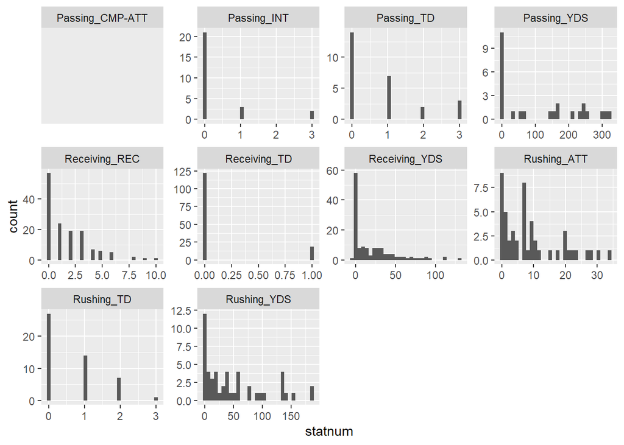

```r
df %>% group_by(stat) %>%
  ggplot(aes(x=statnum)) + geom_histogram(na.rm = TRUE) + facet_wrap(~stat, scales = 'free')
```

### 3)

From the scatterplot below made up of the receiving yards of the ISU players against Oregon and Oklahoma I can see that ISU has better offense against Oklahoma because those data points were further up meaning more recieving yards.

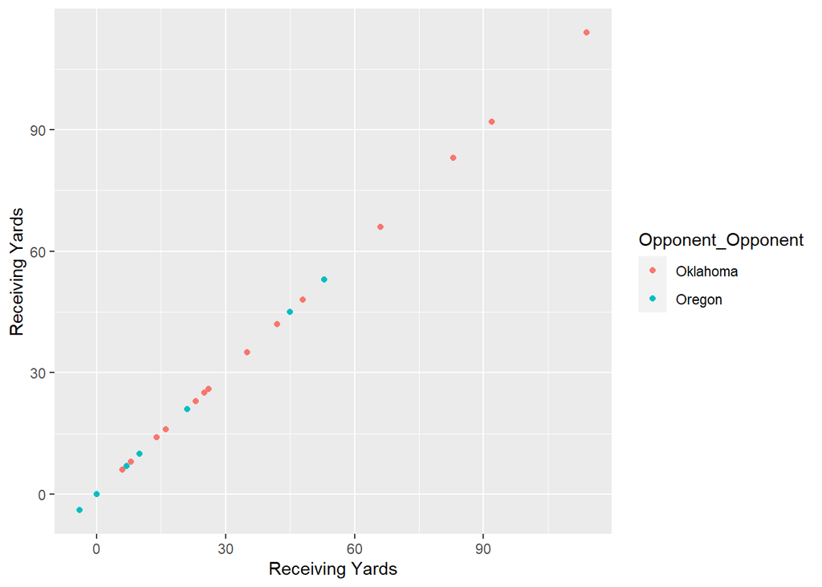

```r
df1 <- df %>% select(Name, Opponent_Opponent,stat, statnum) %>% filter(Opponent_Opponent == 'Oregon' |
                                                   Opponent_Opponent == 'Oklahoma') %>%
  filter(stat == 'Receiving_YDS')
ggplot(df1, aes(x=statnum, y = statnum, color=Opponent_Opponent)) + geom_point() + xlab('Receiving Yards') + ylab('Receiving Yards')
```

### 4)

```r
bio <- bioClean %>% separate(Hometown, c('HTCity', 'HTState'), sep = ', ')
head(bio)
```

```
## # A tibble: 6 x 8
##   Name        Position   Weight Class     HTCity   HTState Highschool   heightIN
##   <fct>       <chr>       <dbl> <chr>     <chr>    <chr>   <chr>           <dbl>
## 1 Akers, Lan~ Wide Rece~    191 Redshirt~ Cedar R~ Iowa    Washington         72
## 2 Allen, Cha~ Tight End     240 Redshirt~ Nixa     Mo.     Nixa               79
## 3 Anderson, ~ Wide Rece~    208 Redshirt~ Seffner  Fla.    Armwood            77
## 4 Antoine Jr~ Defensive~    180 Freshman  Ft. Lau~ Fla.    Cardinal Gi~       72
## 5 Assalley, ~ Placekick~    195 Redshirt~ Napervi~ Ill.    Central            72
## 6 Azunna, Ar~ Defensive~    199 Redshirt~ Grand P~ Texas   Lake Ridge         72
```

### 5)

```r
bio %>% group_by(HTState) %>%
  summarize(Players_from_state =n()) %>%
  arrange(desc(Players_from_state))
```

```
## # A tibble: 21 x 2
##    HTState Players_from_state
##    <chr>                <int>
##  1 Iowa                    42
##  2 Fla.                    14
##  3 Minn.                    8
##  4 Texas                    7
##  5 Ill.                     6
##  6 Ohio                     6
##  7 Mo.                      5
##  8 Ariz.                    4
##  9 Kan.                     4
## 10 Ga.                      3
## # ... with 11 more rows
```

## Part three: Joining data frames

### 1)

From the histogram you can see how many players come from these states. I can see that on both teams a lot of players come from Florida, that’s where the highest count of players on offense come from. On defense, the highest count of players come from Iowa.

```r
biooff <- inner_join(bio, offClean, by = 'Name') %>% select(Name, Position, HTState) %>% mutate(Team = 'Offense')
offState <- biooff %>% group_by(Name) %>%
  summarize(HTState, Team) %>%
  distinct()
biodef <- inner_join(bio, defClean, by = 'Name') %>% select(Name, Position, HTState) %>%
  mutate(Team = 'defense')
defState <- biodef %>% group_by(Name) %>%
  summarize(HTState, Team) %>%
  distinct()
```

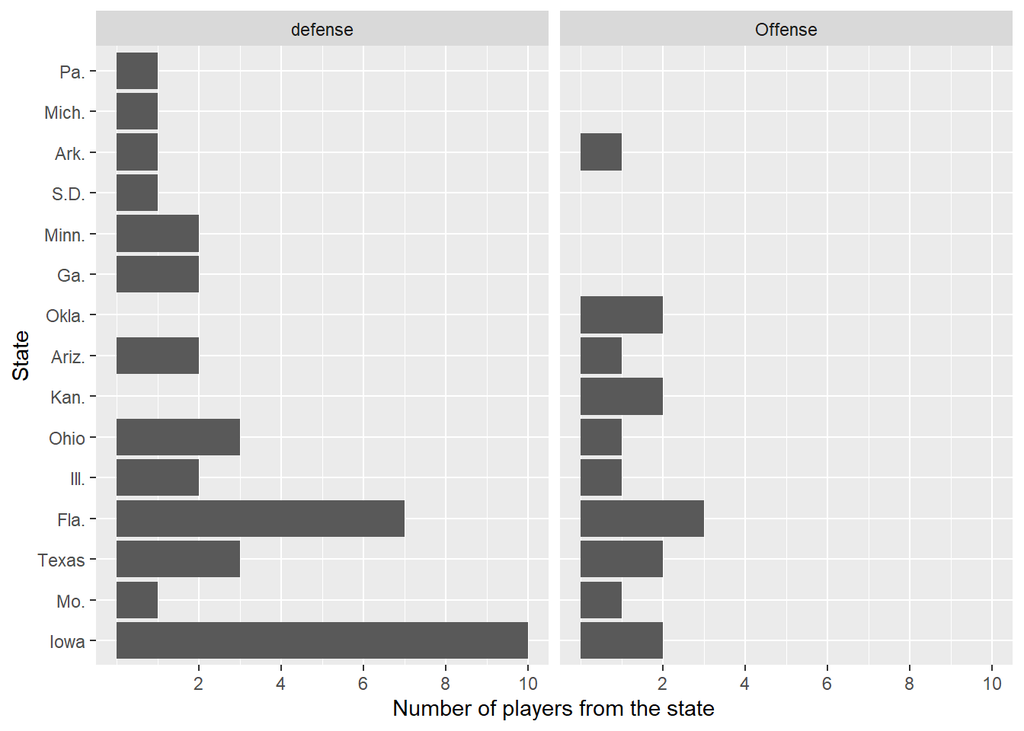

```r
states <- rbind(defState, offState)

totalstates <- states %>% group_by(Team) %>% group_by(HTState) %>%
  summarize(n=n()) %>%
  arrange(desc(n))

states <- states %>% mutate(HTState = as.factor(HTState))
ggplot(states, aes(x=HTState)) + geom_bar() + scale_y_continuous(breaks=c(2,4,6,8,10,12,14)) + xlab('State') + ylab('Number of players from the state') + facet_wrap(~Team) + coord_flip()
```

### 2)

I decided to show how Brock Purdy’s performance relates to the performance of the team by finding the portion of the stats that he contributed to. I divided his stats by the total states off all the games in Offense. The high proportions show that his performance made up a lot of the team’s performance.

```r
purdy <- offClean[offClean$Name == 'Purdy, Brock', ]

purdy <- purdy %>% select(Name, Opponent_Opponent, Rushing_ATT, Rushing_YDS, Rushing_TD, Passing_YDS, Passing_TD, Passing_INT)

purdy2 <- purdy %>% summarize(sum(Rushing_ATT), sum(Rushing_YDS), sum(Rushing_TD),sum(Passing_YDS), sum(Passing_TD), sum(Passing_INT))

team <- offClean %>% select(Name, Opponent_Opponent, Rushing_ATT, Rushing_YDS, Rushing_TD, Passing_YDS, Passing_TD, Passing_INT)

team2 <- team %>% na.omit()%>%
  summarize(sum(Rushing_ATT), sum(Rushing_YDS), sum(Rushing_TD), sum(Passing_YDS), sum(Passing_TD), sum(Passing_INT))

together <- rbind(team2, purdy2) %>% summarize(Rushing_ATT = `sum(Rushing_ATT)`, Rushing_YDS = `sum(Rushing_YDS)`,
                                               Rushing_TD = `sum(Rushing_TD)`, Passing_YDS = `sum(Passing_YDS)`,
                                               Passing_TD = `sum(Passing_TD)`, Passing_INT = `sum(Passing_INT)`)
together[2,]/together[1,]
```

```
##   Rushing_ATT Rushing_YDS Rushing_TD Passing_YDS Passing_TD Passing_INT
## 1   0.9666667   0.9695431  0.8333333   0.9588563       0.95           1
```

### 3)

```r
defense19 <- read_excel('C:/Users/esmyk/oneDrive/DS 202/cyclonesFootball2019.xlsx', sheet='Defensive')
offense19 <- read_excel('C:/Users/esmyk/oneDrive/DS 202/cyclonesFootball2019.xlsx', sheet='Offensive')
biography19 <- read_excel('C:/Users/esmyk/oneDrive/DS 202/cyclonesFootball2019.xlsx', sheet='Biography')
defense19 <- defense19 %>%
  mutate(across(Tackles_Solo:Pass_PB, as.numeric), Name = as.factor(Name),
         Opponent_Opponent = as.factor(Opponent_Opponent))

offense19 <- offense19 %>%
  mutate(across(Rushing_ATT:Passing_INT, as.numeric), Name = as.factor(Name),
         Opponent_Opponent = as.factor(Opponent_Opponent))

data <- offense19 %>% group_by(Name) %>%
  summarize(sum(Rushing_ATT), sum(Rushing_YDS), sum(Rushing_TD),
            sum(Passing_YDS), sum(Passing_TD), sum(Passing_INT),
            sum(Receiving_TD), sum(Receiving_YDS))
data2 <- offClean %>% group_by(Name) %>%
  summarize(sum(Rushing_ATT), sum(Rushing_YDS), sum(Rushing_TD),
            sum(Passing_YDS), sum(Passing_TD), sum(Passing_INT),
            sum(Receiving_TD), sum(Receiving_YDS))
tg <- inner_join(data, data2, by = 'Name')
improvemento <- tg %>% group_by(Name) %>%
  summarize(DiffR_YDS = `sum(Rushing_YDS).y` - `sum(Rushing_YDS).x`, DiffR_TD = `sum(Rushing_TD).y` - `sum(Rushing_TD).x`,
            DiffRE_TD = `sum(Receiving_TD).y`- `sum(Receiving_TD).x`, DiffRE_YDS = `sum(Receiving_YDS).y`- `sum(Receiving_YDS).x`,
            DiffP_YDS = `sum(Passing_YDS).y` - `sum(Passing_YDS).x`, DiffP_TD = `sum(Passing_TD).y` - `sum(Passing_TD).x`)


data3 <- defense19 %>% group_by(Name) %>%
  summarize(sum(Tackles_Solo), sum(Tackles_ASST), sum(Tackles_TFL), sum(Tackles_Sack), sum(Turnover_FF), sum(Turnover_FR),
            sum(Turnover_INT), sum(Pass_QBH), sum(Pass_PB))
data4 <- defClean %>% group_by(Name) %>%
  summarize(sum(Tackles_Solo), sum(Tackles_ASST), sum(Tackles_TFL), sum(Tackles_Sack), sum(Turnover_FF), sum(Turnover_FR),
            sum(Turnover_INT), sum(Pass_QBH), sum(Pass_PB))
tg2 <- inner_join(data3, data4, by = 'Name')
improvementd <- tg2 %>% group_by(Name) %>%
  summarize(DiffT_Solo = `sum(Tackles_Solo).y` - `sum(Tackles_Solo).x`, DiffT_ASST = `sum(Tackles_ASST).y` - `sum(Tackles_ASST).x`,
            DiffT_Sack = `sum(Tackles_Sack).y` - `sum(Tackles_Sack).x`, DiffTu_FF = `sum(Turnover_FF).y` - `sum(Turnover_FF).x`,
            DiffTu_INT = `sum(Turnover_INT).y` - `sum(Turnover_INT).x`, DiffP_QBH = `sum(Pass_QBH).y` - `sum(Pass_QBH).x`)
improvemento
```

```
## # A tibble: 11 x 7
##    Name            DiffR_YDS DiffR_TD DiffRE_TD DiffRE_YDS DiffP_YDS DiffP_TD
##  * <fct>               <dbl>    <dbl>     <dbl>      <dbl>     <dbl>    <dbl>
##  1 Akers, Landen          NA       NA         1        160        NA       NA
##  2 Allen, Chase           NA       NA         0         69        NA       NA
##  3 Brock, Jirehl          -2        0        NA         NA        NA       NA
##  4 Hall, Breece          675       12         1        -72        NA       NA
##  5 Kolar, Charlie         NA       NA         0       -106        NA       NA
##  6 Milton, Tarique        NA       NA        -3       -620        NA       NA
##  7 Nwangwu, Kene         224        4         0         14        NA       NA
##  8 Purdy, Brock          133       -3        NA         NA     -1232       -8
##  9 Scates, Joe            NA       NA         1        109        NA       NA
## 10 Shaw Jr., Sean         NA       NA        -4        -19        NA       NA
## 11 Soehner, Dylan         NA       NA        -1         98        NA       NA
```

```r
improvementd
```

```
## # A tibble: 15 x 7
##    Name          DiffT_Solo DiffT_ASST DiffT_Sack DiffTu_FF DiffTu_INT DiffP_QBH
##  * <fct>              <dbl>      <dbl>      <dbl>     <dbl>      <dbl>     <dbl>
##  1 Akers, Landen         -6          2        0           0          0         0
##  2 Azunna, Arno~         -3          2       -0.5         0          0        -1
##  3 Bailey, JaQu~         18         10        7           1          0         0
##  4 Hummel, Jake          15         26        0           1         -1         3
##  5 King, Kym-Ma~          0          1        0           0          0         0
##  6 Kyle, Tayvonn         -2          1       -0.5         0          1         0
##  7 Petersen, Za~        -16         -6       -1          -1          0        -3
##  8 Rose, Mike            15          4       -2          -1          4         3
##  9 Rus, Jared             2         -1        0           0          0         0
## 10 Soehner, Dyl~         -2          0        0           0          0         0
## 11 Uwazurike, E~         -3         -2        1.5         0          0        -1
## 12 Vance, O'Rien         -4          6       -5.5        -1          0        -8
## 13 Vaughn, Gerry          9         12        0           0          0         0
## 14 Walling, Rory          3          0        0           0          0         0
## 15 Young, Datro~          6          0        0           0          0         0
```